# Project Group - 10

Splinter Groenink: 5170672  
Ton van Mameren: 6108466  
Gijs Volkers: 5295920  
Hidde Voogt: 5886694  
Justin Wagenaar: 5088259

# Research Objective

The COVID-19 pandemic caused big changes to human's travel behaviour. Research shows that the main reasons for travel, choice of transportation mode, travel distance, and trip frequency for primary journeys differed considerably before and during the pandemic. For example there was a notable shift from public transportation toward private vehicles and non-motorized modes (Abdullah et al., 2020). There is not much research about how this behaviour changed after the pandemic. Another intersting question is about whether there also is a difference on people's travel behaviour depending on where they live(urbanised vs. non-urbanised). To answer these questions, this report adresses the following research question:

What are the differences in transportation modes used in different urbanization-level areas before, during, and after the COVID-19 pandemic?

This research question is answered with the following subquestions:

- How did the amount of travel time change across periods in different urbanization levels (in hours)? This subquestion investigates how the total time people spent traveling shifted during the pandemic. Examining changes in travel time across urban, suburban, and rural areas can reveal how individuals in different settings adapted their travel habits in response to the pandemic.
- How did passenger kilometers vary across different periods in the different urbanization levels? Passenger kilometers measure the distance traveled per person across various transportation modes. By assessing this statistic across urbanization levels, shifts in overall travel distances can be understood. Changes in passenger kilometers provide insight into whether people in various regions continued commuting long distances or opted for shorter, more localized travel.
- How did the number of trips vary across different transportation modes and periods? This question examines the frequency of trips taken across different transportation modes (e.g., cars, public transit, bicycles) during the pandemic. By tracking trip frequency over time, this analysis reveals shifts in transportation preferences and the extent to which different modes were utilized or avoided. This is particularly relevant for public transportation, which was heavily impacted by health concerns and restrictions.

In the first section the datasources and the data pipeline is explained. Afterwards, each subquestion is answered and visualised. Finally the report ends with a conclusion to summarise the findings from the data.

# Contribution Statement

**Splinter Groenink**: Distance subquestion & discussion

**Ton van Mameren**: Trips subquestion

**Gijs Volkers**: Data, Data processing, map plot & final report check

**Hidde Voogt**: Travel hours subquestion & conclusion

**Justin Wagenaar**: Animated plots & introduction

```python
# import packages and local helper functions

# Packages
import pandas as pd
import geopandas as gpd
import matplotlib.pyplot as plt
import seaborn as sns
import plotly.express as px

# Local imports, helper funtions
from helper_functions.data_rename import *
from helper_functions.map_maker import *
from helper_functions.functions_trips import *
from helper_functions.passenger_km_time import *
from helper_functions.barplot_animation import *
from helper_functions.function_travel_hours import *
```

# Data Used

All data in this project comes from the Central Bureau of Statistics (CBS). The CBS is a Dutch government organization whose main task is to make statistics on societal topics and publish them. Think of subjects like population growth, inflation, crime, imports and exports, etc. But therefore also topics such as corona, mobility and data per municipality/region. This data is collected by CBS by surveying companies, individuals, but also by analyzing registers. CBS is a reputable government organization that has reliable information because they have lots and lots of good data. Moreover, they always indicate in their data how precise the data is by always indicating the upper and lower bound of the data. Moreover, they always state how they calculated the data and what exactly the data indicates.

#### This project used two datasets from CBS, Mobility Data (2018-2023) and Geospatial Data (Wijk- en Buurtkaart 2020).

**Mobility data (2018-2023).**

The mobility dataset provides a detailed overview of the travel behavior of Dutch citizens. Data is available on multiple modes of transportation, frequency of trips, and distances traveled, broken down by region and degree of urbanization. The data contains the following columns:

```python
# Open and show mobility data

file_path = 'raw_data/84710ENG_TypedDataSet_30092024_142837.csv'
data_raw = pd.read_csv(file_path, delimiter=';', encoding='utf-8')

data_raw.head()
```

|  | ID | TravelMotives | Population | TravelModes | Margins | RegionCharacteristics | Periods | Trips_1 | DistanceTravelled_2 | TimeTravelled_3 | Trips_4 | DistanceTravelled_5 | TimeTravelled_6 |
| --- | --- | --- | --- | --- | --- | --- | --- | --- | --- | --- | --- | --- | --- |
| 0 | 0 | T001080 | A048710 | T001093 | MW00000 | NL01 | 2018JJ00 | 2.78 | 36.16 | 74.60 | 1015.0 | 13200.0 | 453.8 |
| 1 | 1 | T001080 | A048710 | T001093 | MW00000 | NL01 | 2019JJ00 | 2.71 | 36.00 | 74.39 | 989.0 | 13140.0 | 452.6 |
| 2 | 2 | T001080 | A048710 | T001093 | MW00000 | NL01 | 2020JJ00 | 2.35 | 24.88 | 61.96 | 861.0 | 9105.0 | 378.0 |
| 3 | 3 | T001080 | A048710 | T001093 | MW00000 | NL01 | 2021JJ00 | 2.51 | 27.24 | 69.85 | 915.0 | 9942.0 | 424.9 |
| 4 | 4 | T001080 | A048710 | T001093 | MW00000 | NL01 | 2022JJ00 | 2.70 | 30.21 | 72.69 | 984.0 | 11027.0 | 442.2 |

**Geospatial data (Wijk- en buurtkaart 2020).**

The geospatial dataset provides geographic information at the neighbourhood and district level. This map contains spatial classifications of the Netherlands, including detailed descriptions of areas such as degree of urbanisation and socioeconomic characteristics. Linking this data to the mobility data makes the data easier to understand, as the data can be linked to the different municipalities in the Netherlands. There is a lot of data in this file, but here are the main columns, look especially Here for more information about this dataset.

```python
# Open and show geospatial data

gemeenten = gpd.read_file('WijkBuurtkaart_2020_v3/gemeente_2020_v3.shp')

gemeenten.head()
```

|  | GM_CODE | GM_NAAM | H2O | OAD | STED | BEV_DICHTH | AANT_INW | AANT_MAN | AANT_VROUW | P_00_14_JR | ... | AV20PODIUM | AF_MUSEUM | AV5_MUSEUM | AV10MUSEUM | AV20MUSEUM | JRSTATCODE | JAAR | Shape_Leng | Shape_Area | geometry |
| --- | --- | --- | --- | --- | --- | --- | --- | --- | --- | --- | --- | --- | --- | --- | --- | --- | --- | --- | --- | --- | --- |
| 0 | GM0010 | Delfzijl | JA | -99999999 | -99999999 | -99999999 | -99999999 | -99999999 | -99999999 | -99999999 | ... | -99999999.0 | -99999999.0 | -99999999.0 | -99999999.0 | -99999999.0 | 2020GM0010 | 2020 | 128728.007061 | 9.129235e+07 | MULTIPOLYGON (((268674.309 592382.331, 268667.... |
| 1 | GM0034 | Almere | JA | -99999999 | -99999999 | -99999999 | -99999999 | -99999999 | -99999999 | -99999999 | ... | -99999999.0 | -99999999.0 | -99999999.0 | -99999999.0 | -99999999.0 | 2020GM0034 | 2020 | 122665.358634 | 1.095623e+08 | MULTIPOLYGON (((150213.998 479503.726, 150087.... |
| 2 | GM0050 | Zeewolde | JA | -99999999 | -99999999 | -99999999 | -99999999 | -99999999 | -99999999 | -99999999 | ... | -99999999.0 | -99999999.0 | -99999999.0 | -99999999.0 | -99999999.0 | 2020GM0050 | 2020 | 83290.773617 | 1.633050e+07 | MULTIPOLYGON (((154927.535 474979.290, 154931.... |
| 3 | GM0060 | Ameland | JA | -99999999 | -99999999 | -99999999 | -99999999 | -99999999 | -99999999 | -99999999 | ... | -99999999.0 | -99999999.0 | -99999999.0 | -99999999.0 | -99999999.0 | 2020GM0060 | 2020 | 156406.894023 | 2.085914e+08 | POLYGON ((196000.000 610000.000, 196000.000 60... |
| 4 | GM0072 | Harlingen | JA | -99999999 | -99999999 | -99999999 | -99999999 | -99999999 | -99999999 | -99999999 | ... | -99999999.0 | -99999999.0 | -99999999.0 | -99999999.0 | -99999999.0 | 2020GM0072 | 2020 | 104274.683036 | 3.618323e+08 | MULTIPOLYGON (((158392.775 580357.500, 158387.... |

5 rows × 205 columns

### Data Transformation

The CBS data was very unclearly structured, using many codes, making it difficult to decipher exactly what was in each line. Therefore, we decided to make the information in the rows readable by converting codes to readable values.

What is also important to mention is that we only used the value and not the upper and lower bound. We know CBS has good data, so we chose for simplicity to use only the value.

```python
# Transform the dataset to make it readable

data = make_named_clean_dataset(data_raw)

data.head()
```

```
Named And Cleaned Data After Dropping Missing Values: (1698, 13)
```

|  | ID | Trips_Per_Day | Distance_Travelled_PassengerKm_Per_Day | Time_Travelled_Minutes_Per_Day | Trips_Per_Year | Distance_Travelled_PassengerKm_Per_Year | Time_Travelled_Hours_Per_Year | TravelMotives | Population | TravelModes | Margins | RegionCharacteristics | Period |
| --- | --- | --- | --- | --- | --- | --- | --- | --- | --- | --- | --- | --- | --- |
| 102 | 102 | 2.70 | 32.66 | 77.71 | 987.0 | 11922.0 | 472.7 | Total | Population 6 years or older | Total | Value | Extremely urbanised | 2018 |
| 103 | 103 | 2.59 | 31.41 | 76.64 | 947.0 | 11464.0 | 466.2 | Total | Population 6 years or older | Total | Value | Extremely urbanised | 2019 |
| 104 | 104 | 2.14 | 20.77 | 61.54 | 782.0 | 7601.0 | 375.4 | Total | Population 6 years or older | Total | Value | Extremely urbanised | 2020 |
| 105 | 105 | 2.33 | 23.02 | 71.00 | 852.0 | 8402.0 | 431.9 | Total | Population 6 years or older | Total | Value | Extremely urbanised | 2021 |
| 106 | 106 | 2.52 | 25.44 | 72.81 | 918.0 | 9287.0 | 442.9 | Total | Population 6 years or older | Total | Value | Extremely urbanised | 2022 |

### Information urbanization rate

To get a good idea of the different degrees of urbanization, we created a plot that looks at the degree of urbanization for each municipality. This makes the data we put down further in the report a lot easier to understand because the reader can relate it to the different municipalities in the Netherlands.

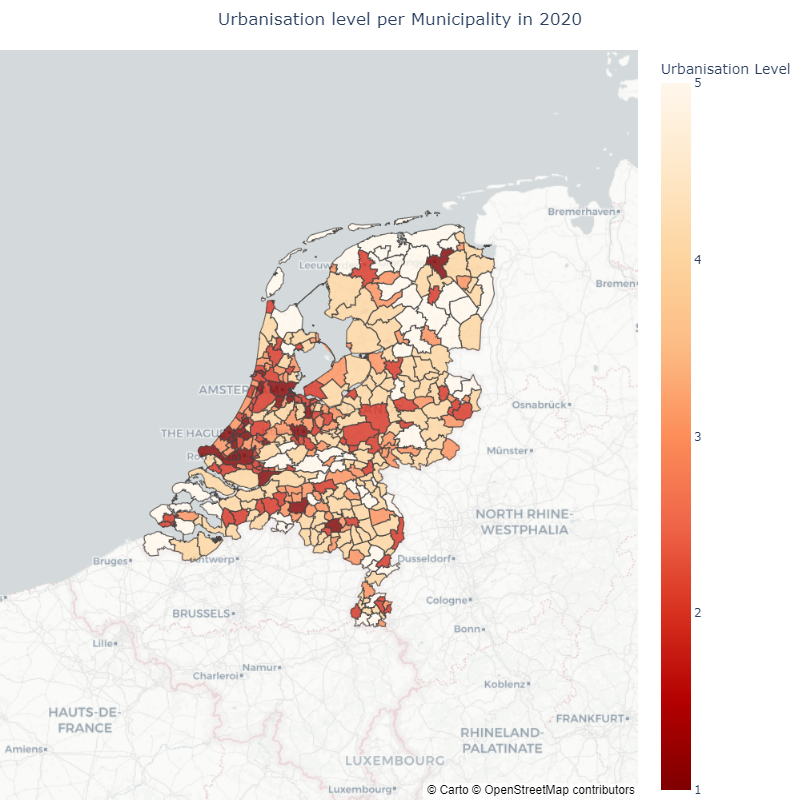

```python
# This map is too large in data to upload to github... Use picture above to see the map
# Uncommenting the line below and running still works if needed

generate_map('WijkBuurtkaart_2020_v3/gemeente_2020_v3.shp')
```

## Figures

We used Plotly for most of the graphs, however, **plotly graphs cannot be renderen in github online**. We added the pictures of the plots in the report if you do not want to download the reporisory. If you download the report you will be able to see the plots like they were intended.

# Data Pipeline

## How did amount of travel time across periods in the different urbanisation levels (in hours) ?

Understanding the variation travel time for passengers before, during and after the COVID-19 pandemic indicates how travel behaviour might have changed due to the pandemic. These results are cross-checked with the level of urbanisation and provides new insights. A variation of graphs are presented below. Both the graphs contain data from 2018-2023. The COVID-19 pandemic had significant effects on the travel time in 2020, as time furthers travel time augments again. The line plot displays, in line with the expectation, a sharp decline in travel time in 2020 (during the first 'hard'lock-down). It then continues to rise but not evenly across urbanisation level. The areas which were labelled as 'not urbanised' did not climb as fast as the other levels of urbanisation. This could, perhaps, be attributed to the amount of people that work 'remote' and would have to travel further than other people in different urbanisation areas.

The heatmap underscores these trends with a visual representation of travel time variations. Brighter colors, indicating higher travel times, show a clear decline in 2020 across all regions. However, in the post-pandemic years, the colors reveal a gradual return to increased travel, with urbanized regions showing a more intense recovery. Notably, areas with lower urbanization remain shaded in darker colors, signaling that pre-COVID levels have yet to fully return.

These findings suggest that remote work and telecommuting may have a lasting impact, particularly in non-urbanized areas, where travel patterns may have fundamentally shifted due to the pandemic. This data could indicate a new equilibrium for travel demand, especially if remote work policies persist

**Images because github is not able to handle plotly graphs**

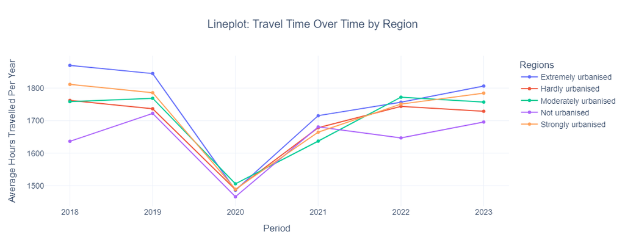

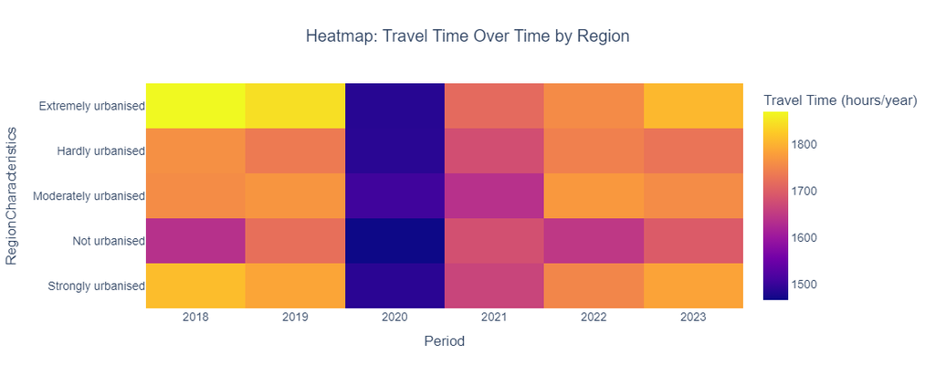

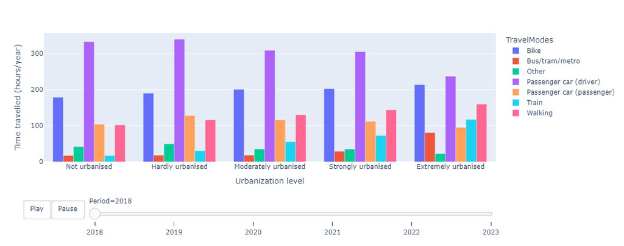

```python
# Make plot for travelhours

datanototal = data[data['TravelModes'] != 'Total']  # Exclude 'Total' for graphs

plot_travelhours()

barplotanimation(datanototal, 'Time_Travelled_Hours_Per_Year', 'Time travelled (hours/year)')
```

## Analysis of Passenger Kilometers Across Different Urban Areas (2018–2023)

### Passenger Kilometers Over Time

The line chart reveals a sharp decline in passenger kilometers for all areas in 2020, aligning with the start of the pandemic. Highly urbanized areas experienced one of the most significant drops. This decrease reflects strict lockdowns, the rise of remote work, and health concerns that kept people at home.

**Images because github is not able to handle plotly graphs**

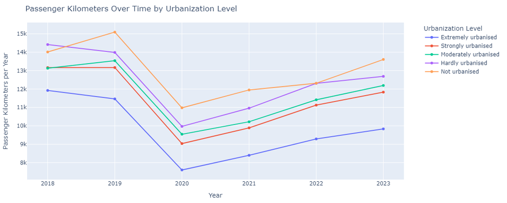

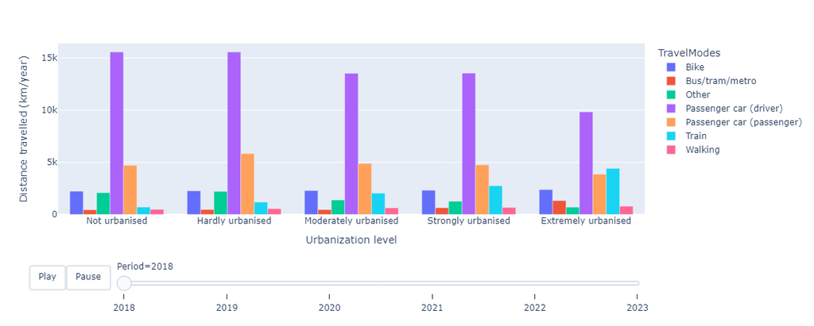

```python
passenger_km_plot(data)
```

```python
barplotanimation(datanototal, 'Distance_Travelled_PassengerKm_Per_Year', 'Distance travelled (km/year)')
```

### Conclusion

The pandemic caused a significant drop in passenger kilometers across all areas in 2020. The less urbanized areas came back more quickly, possibly due to personal vehicle use and fewer restrictions. The higher urbanized areas recovered more slowly. These findings suggest that while there were temporary changes in travel patterns, there may also be lasting effects on how people in highly urbanized areas choose to travel in the future.

## How did the number of trips vary across different transportation modes and periods?

In this part of the report, we will look at how the number of trips vary across different transportation modes and periods. Firstly, we will look at the global trend without specify for the transportation modes. This trend can be seen in the figure below.

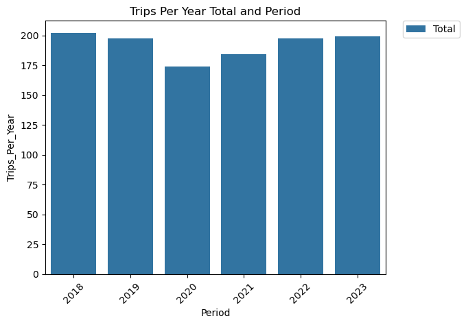

```python
trips_per_year_total_and_period(data)
```

In the figure above, for each period (pre, during and after COVID-19) the total trips per year for all transportation modes are plotted. We can see a decrease in the number of trips per year in the year 2020, in that year COVID-19 started. Furthermore, we can see the effect from the measurments taken to reduce the virus, which resulted in fewer trips. In 2021, it was still COVID-19 time, however less was closed then during 2020. In 2022 and 2023, the number of trips per year went (almost) back to the pre COVID-19 level.

In the next figures, the number of trips will be specified for the different transportation modes.

**Image because github is not able to handle plotly graphs**

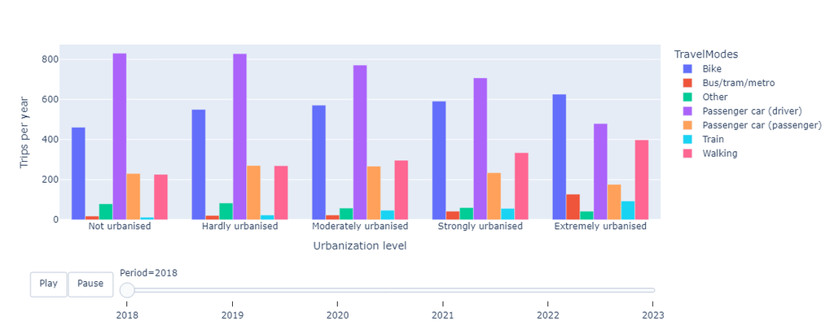

```python
barplotanimation(datanototal, 'Trips_Per_Year', 'Trips per year')
```

In the figure above, the number of trips taking each year have been specified. Just as the figure for all transportation modes together, the decrease in trips for the transportation modes can be seen. However, if we look specific for the mode walking something different can be seen. The number of trips for walking increased during COVID-19. Since many sport activities could not continue during COVID-19 and people had to stay at home, people started looking for other simple activiteit that were allowed to do during COVID_19. Walking alone or with a friend at 1.5m distance was one of the activities that many people started doing and can be seen in the figure above. The number of trips from the other transportation modes decreased during COVID-19.

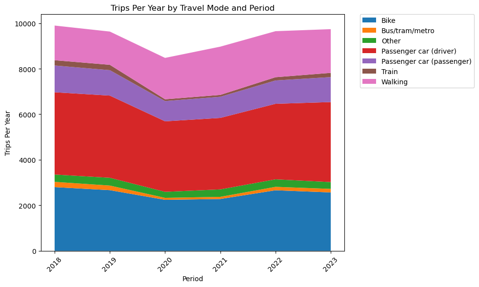

```python
area_chart_trips(data)
```

In the visualization above, the first two figures are combined. The total number of trips for each year can still be seen, which is the sum of all transportation modes. Within the total, the different transportation modes are defined with colours. The bigger the area of a colour, the higher the number of trips for that specific transportation mode in that year.

## Discussion and limitations:

For most of the research, only one dataset was used. The dataset was based on a CBS dataset that gave an overview of the travel behaviour of Dutch citizens. The data set provided insight into the travel behaviour of Dutch citizens but lacked specific data for real research into travel patterns. The CBS dataset is based on aggregated survey data, which may overlook individual variations in travel patterns. External factors such as seasonal effects, fuel prices, or temporary disruptions in public transportation are not controlled for. These kinds of external factors can have an impact on travel behaviour. The study does not consider variations in employment types or flexibility in remote work across regions, which likely influenced recovery rates but were not explicitly accounted for. These limitations suggest that while the study provides valuable insights into pandemic-related changes in travel behaviour, a more comprehensive dataset and additional controls are necessary for a full understanding of the underlying factors influencing these shifts.

## References

Abdullah, M., Dias, C., Muley, D., & Shahin, M. (2020). Exploring the impacts of COVID-19 on travel behavior and mode preferences. Transportation Research Interdisciplinary Perspectives, 8, 100255. https://doi.org/10.1016/j.trip.2020.100255